# Stat 245 – Vermeer Ready-To-Analyze Datasets

Adham Rishmawi, Aubrey Williams, Daniel Kwik, Misgana Dinberu

November 29, 2022

## Project Question

#### Question: Which characteristics are most strongly associated with the number of repairs of a given machine?

Hypothesis: Machine hours, down time, and sum of n_red are the predictors that are most strongly associated with the number of repairs on a given machine which is directly proportional to the amount of money it costs Vermeer to repair them (i.e the higher the machine hours- the higher the number of repairs which in turn affect the amount of money Vermeer has to pay to repair)

This is our hypothesis on what variables can predict this:

-The length of time between a machine’s failure, and when it was repaired.

-The type / category of machine failure

-The model of machine

-The number of hours machine was running for before it broke down

## Planning Process:

These are the six data sets we will be using. I have loaded up the data and included a glimpse into them to see what there is.

```r
# This loads in the vin-pin numbers
vinpin_data <- read_csv("VINPINdata.csv")
glimpse(vinpin_data)
```

```
## Rows: 18,183
## Columns: 3
## $ assetId   <dbl> 216049, 216050, 216051, 216052, 216053, 216054, 216055, 2160…
## $ name      <chr> "D220X300: 122", "D24X40II: 4132", "HG4000: 181", "D36X50II:…
## $ `VIN/PIN` <chr> "1VRD370C5E1000122", "1VRZ19037E1004132", "1VRC312H8E1000181…
```

```r
# This loads in specific data regarding the drill.
instprod_dtc_drills_azure <- read_csv("Intsprod_dtc_azure.csv")
glimpse(instprod_dtc_drills_azure)
```

```
## Rows: 87,574
## Columns: 16
## $ `VIN/PIN`                      <chr> "1VRX200F8G1000281", "1VRX200F5K1000845…
## $ OFFICIAL_MODEL_NAME            <chr> "D24X40III", "D24X40III", "D24X40III", …
## $ TROUBLECODETIMESTAMP           <chr> "14-NOV-19 11.14.33.000000000 AM", "14-…
## $ REDSTOPFLASHLAMPSTATUS         <dbl> 0, 0, 0, 0, 0, 0, 0, 0, 0, 0, 0, 0, 0, …
## $ REDSTOPLAMPSTATUS              <dbl> 1, 0, 0, 1, 0, 0, 0, 1, 0, 0, 1, 0, 0, …
## $ AMBERWARNINGLAMPSTATUS         <dbl> 0, 0, 1, 0, 0, 1, 1, 0, 1, 0, 0, 1, 1, …
## $ AMBERWARNINGFLASHLAMPSTATUS    <dbl> 0, 0, 0, 0, 0, 0, 0, 0, 0, 0, 0, 0, 0, …
## $ PROTECTLAMPSTATUS              <dbl> 0, 0, 0, 0, 0, 0, 0, 0, 0, 0, 0, 0, 0, …
## $ MALFUNCTIONINDICATORLAMPSTATUS <dbl> 0, 0, 0, 0, 0, 0, 0, 0, 0, 0, 0, 0, 0, …
## $ LAMP_STATUS                    <chr> "RED", "NONE", "AMBER", "RED", "NONE", …
## $ CANBUS                         <dbl> 1, 0, 1, 1, 0, 1, 1, 1, 1, 0, 1, 0, 1, …
## $ SOURCEADDRESS                  <dbl> 200, 0, 198, 193, 0, 200, 198, 193, 198…
## $ PGN                            <dbl> NA, NA, NA, NA, NA, NA, NA, NA, NA, 652…
## $ SPN                            <dbl> 520239, 168, 520889, 2194, 168, 520239,…
## $ FMI                            <chr> "18", "18", "14", "09", "18", "14", "14…
## $ OCCURENCECOUNT                 <dbl> 1, 1, 1, 1, 1, 1, 1, 1, 1, 1, 1, 1, 1, …
```

```r
# This loads in all the different drills D20X-60X.
azure_D20X_60X <- read_csv("Azure_D20-60X.csv")
glimpse(azure_D20X_60X)
```

```
## Rows: 867,889
## Columns: 18
## $ AssetId                             <dbl> 279594, 312266, 307135, 291266, 29…
## $ name                                <chr> "D20X22III: 2684", "D20X22III: 318…
## $ TroubleCodeTimeStamp                <dttm> 2022-09-20 12:03:38, 2022-09-20 1…
## $ RedStopFlashLampStatus              <dbl> 3, 3, 0, 0, 0, 0, 0, 0, 0, 3, 0, 0…
## $ RedStopLampStatus                   <dbl> 1, 1, 0, 0, 0, 0, 0, 0, 0, 1, 0, 0…
## $ AmberWarningLampStatus              <dbl> 0, 0, 1, 1, 1, 1, 1, 1, 1, 0, 1, 1…
## $ AmberWarningFlashLampStatus         <dbl> 0, 0, 3, 3, 3, 3, 3, 3, 3, 0, 3, 3…
## $ ProtectLampStatus                   <dbl> 0, 0, 0, 0, 0, 0, 0, 0, 0, 0, 0, 0…
## $ ProtectFlashLampStatus              <dbl> 0, 0, 0, 0, 0, 0, 0, 0, 0, 0, 0, 0…
## $ MalfunctionIndicatorLampStatus      <dbl> 0, 0, 0, 0, 0, 0, 0, 0, 0, 0, 0, 0…
## $ MalfunctionIndicatorFlashLampStatus <dbl> 0, 0, 0, 0, 0, 0, 0, 0, 0, 0, 0, 0…
## $ CanBus                              <dbl> 0, 1, 0, 0, 1, 0, 1, 1, 1, 0, 0, 0…
## $ SourceAddress                       <dbl> 0, 0, 0, 0, 0, 0, 0, 0, 0, 0, 0, 0…
## $ Spn                                 <dbl> 523698, 523698, 523613, 523470, 52…
## $ Fmi                                 <dbl> 11, 11, 1, 14, 14, 14, 6, 3, 4, 12…
## $ LAMPSTATUS                          <chr> "RED", "RED", "AMBER", "AMBER", "A…
## $ ReportType                          <dbl> 2, 2, 2, 2, 2, 2, 2, 2, 2, 2, 2, 2…
## $ OccurenceCount                      <dbl> NA, NA, NA, NA, NA, NA, NA, NA, NA…
```

```r
# This loads in a work order which holds all the same information about different drills.
work_order1 <- read_csv("Work-order org/work_order.csv")
glimpse(work_order1)
```

```
## Rows: 122,904
## Columns: 7
## $ IDENTIFICATION <chr> "1VRN20074F1000115", "1VRA170V7G1000507", "1VRN20075H10…
## $ MODEL          <chr> "D23X30III", "D20X22III", "D23X30III", "D36X50II", "D23…
## $ WO_SEQ_ID      <dbl> 178340, 179512, 178290, 179853, 178577, 177075, 177358,…
## $ MACHINE_HOURS  <dbl> 1770, 835, 990, 2080, 767, 2146, 177, 598, 672, 86, 0, …
## $ CREATED_DATE   <chr> "11-Jan-18", "19-Jan-18", "11-Jan-18", "23-Jan-18", "13…
## $ FAILURE_DATE   <chr> "4-Jan-18", "4-Dec-17", "4-Dec-17", "29-Nov-17", "31-Oc…
## $ REPAIR_DATE    <chr> "11-Jan-18", "18-Jan-18", "11-Jan-18", "22-Jan-18", "12…
```

```r
# This loads in a second work order which holds all the same information about different drills.
work_order2 <- read_csv("Work-order org/work_order2.csv")
glimpse(work_order2)
```

```
## Rows: 425,252
## Columns: 7
## $ IDENTIFICATION    <chr> "1VRA170V8H1000937", "1VRN20073F1000106", "1VRN20073…
## $ MODEL             <chr> "D20X22III", "D23X30III", "D23X30III", "D23X30III", …
## $ WO_SEQ_ID         <dbl> 180651, 180666, 180666, 180669, 179357, 183040, 1830…
## $ CREATED_DATE      <chr> "25-Jan-18", "25-Jan-18", "25-Jan-18", "25-Jan-18", …
## $ PART_NUMBER       <chr> "296438394", "296285658", "296411788", "296454327", …
## $ PART_NAME         <chr> "PLANETARY-MOTOR ASSEMBLY", "CYLINDER 1 X 3-1/2", "P…
## $ `SUM(B.QUANTITY)` <dbl> 1, 1, 1, 1, 4, 1, 1, 1, 2, 1, 1, 1, 17, 3, 1, 1, 2, …
```

```r
# # This loads in a third work order which holds all the same information about different drills.
work_order3 <- read_csv("Work-order org/work_order3.csv")
glimpse(work_order3)
```

```
## Rows: 174,179
## Columns: 7
## $ IDENTIFICATION  <chr> "1VRN2007XH1000655", "1VR4230D1B1000831", "1VRA170V2H1…
## $ MODEL           <chr> "D23X30III", "D36X50II", "D20X22III", "D24X40III", "D2…
## $ WO_SEQ_ID       <dbl> 183707, 183943, 184163, 184166, 184166, 184167, 184755…
## $ CREATED_DATE    <chr> "7-Feb-18", "8-Feb-18", "8-Feb-18", "8-Feb-18", "8-Feb…
## $ JOB_CODE_NUMBER <chr> "9045V", "8068V", "SB16-135", "A006V-000", "M005V-001"…
## $ JOB_CODE_DESC   <chr> "9045 - Water/Mud Pump Casting/Housing R&R CMP", "8068…
## $ ACTUAL_HOURS    <dbl> 3.54, 1.72, 0.10, 1.25, 4.00, 0.25, 1.72, 1.66, 4.50, …
```

## Prepare and Merge

Steps:

### Append VIN to the Azure datasets using AssetID as the connection

```r
azure_with_vin <- azure_D20X_60X |>
  left_join(vinpin_data |> select(assetId, `VIN/PIN`),
            # next line needed since name (spelling) of assetId column is not same across datasets
            by = c('AssetId' = 'assetId')) |>
    separate(name, into = c('model', NA), sep = ':', remove = FALSE)
```

### Group Azure datasets by VIN and summarize the variables

```r
azure_summary <- azure_with_vin |>
  group_by(`VIN/PIN`) |>
  summarise(n_red = sum(LAMPSTATUS == "RED", na.rm = TRUE),
            n_amber = sum(LAMPSTATUS == 'AMBER', na.rm = TRUE),
            n_notification = sum(LAMPSTATUS == 'NOTIFICATION', na.rm = TRUE),
            n_malfunction = sum(LAMPSTATUS == 'MALFUNCTION', na.rm = TRUE),
            model = first(model)

  ) |>
  ungroup()
```

### Group WorkOrder by VIN and summarize

```r
# paste together all 3 work order data sets
all_work_orders <- bind_rows(work_order1, work_order2, work_order3) |>
    # you didn't ask for this but in case it's useful: duration of repair
  mutate(down_time = difftime(lubridate::dmy(REPAIR_DATE),
                              lubridate::dmy(FAILURE_DATE),
                              units = 'hours'),
         down_time = as.numeric(down_time))

work_order_summary <- all_work_orders |>
  # now group by machine VIN
  group_by(IDENTIFICATION) |>
  # summarise info for all work orders on this machine
  summarise(n_work_orders = n(),
            mean_machine_hours = mean(MACHINE_HOURS, na.rm = TRUE),
            median_machine_hours = median(MACHINE_HOURS, na.rm = TRUE),
            mean_down_time = mean(down_time, na.rm = TRUE),
            median_down_time = median(down_time, na.rm = TRUE),
            max_machine_hours = max(MACHINE_HOURS, na.rm = TRUE))
```

### Inner join the grouped Azure dataset onto the grouped WorkOrder dataset

```r
summary_by_machine <-
  inner_join(work_order_summary, azure_summary,
            by = c("IDENTIFICATION" = "VIN/PIN"))
glimpse(summary_by_machine)
```

```
## Rows: 2,421
## Columns: 12
## $ IDENTIFICATION       <chr> "1VR3240M0J1000108", "1VR3240M1L1000203", "1VR324…
## $ n_work_orders        <int> 433, 85, 171, 628, 388, 166, 70, 270, 133, 269, 1…
## $ mean_machine_hours   <dbl> 1641.24762, 193.80952, 416.65000, 1475.61935, 476…
## $ median_machine_hours <dbl> 1333.0, 12.0, 379.0, 967.0, 50.0, 401.0, 679.0, 1…
## $ mean_down_time       <dbl> 1181.7143, 982.8000, 1259.4000, 1176.6194, 457.45…
## $ median_down_time     <dbl> 1152, 540, 252, 840, 336, 336, 528, 480, 336, 276…
## $ max_machine_hours    <dbl> 3910, 516, 1401, 3854, 1884, 1681, 3836, 5000, 15…
## $ n_red                <int> 179, 15, 239, 222, 458, 475, 459, 1303, 484, 226,…
## $ n_amber              <int> 414, 28, 45, 317, 102, 210, 113, 1148, 346, 546, …
## $ n_notification       <int> 223, 22, 30, 656, 124, 124, 111, 1610, 230, 1713,…
## $ n_malfunction        <int> 5, 0, 0, 0, 0, 0, 0, 0, 0, 65, 0, 8, 0, 0, 0, 20,…
## $ model                <chr> "D40X55DRS3", "D40X55DRS3", "D40X55DRS3", "D40X55…
```

Now: There aren’t *any* NAs in `work_order_summary` so NAs in the `n_...` columns should actually be 0s: no downtime, no work order at all. So to fill those in:

```r
summary_by_machine <- summary_by_machine |>
  # in columns from n_work_orders to median_down_time,
  mutate(across(c(n_work_orders : median_down_time),
                # replace NAs with  0s
                ~replace_na(.x, replace = 0)))

glimpse(summary_by_machine)
```

```
## Rows: 2,421
## Columns: 12
## $ IDENTIFICATION       <chr> "1VR3240M0J1000108", "1VR3240M1L1000203", "1VR324…
## $ n_work_orders        <int> 433, 85, 171, 628, 388, 166, 70, 270, 133, 269, 1…
## $ mean_machine_hours   <dbl> 1641.24762, 193.80952, 416.65000, 1475.61935, 476…
## $ median_machine_hours <dbl> 1333.0, 12.0, 379.0, 967.0, 50.0, 401.0, 679.0, 1…
## $ mean_down_time       <dbl> 1181.7143, 982.8000, 1259.4000, 1176.6194, 457.45…
## $ median_down_time     <dbl> 1152, 540, 252, 840, 336, 336, 528, 480, 336, 276…
## $ max_machine_hours    <dbl> 3910, 516, 1401, 3854, 1884, 1681, 3836, 5000, 15…
## $ n_red                <int> 179, 15, 239, 222, 458, 475, 459, 1303, 484, 226,…
## $ n_amber              <int> 414, 28, 45, 317, 102, 210, 113, 1148, 346, 546, …
## $ n_notification       <int> 223, 22, 30, 656, 124, 124, 111, 1610, 230, 1713,…
## $ n_malfunction        <int> 5, 0, 0, 0, 0, 0, 0, 0, 0, 65, 0, 8, 0, 0, 0, 20,…
## $ model                <chr> "D40X55DRS3", "D40X55DRS3", "D40X55DRS3", "D40X55…
```

#### Interpretation: This our final data set. The final data set holds the columns:

`Identification`: vin/pin of the model

`n_work_orders`: count of work orders.

`mean_machine_hours`: mean of the machine hours recorded.

`median_machine_hours`: median of the machine hours recorded.

`mean_down_time`: mean of the downtime (difference of repair date and failure date)

`median_down_time`: median of the downtime (difference of repair date and failure date)

`n_red`: this is the count of the red lamp status

`n_amber`: this is the count of the amber lamp status.

`n_notification`: this is the count of the notification lamp status.

`n_malfunction`: this is the count of the malfunction lamp status.

`model`: the model name of the machine

## Exploratory Graphs

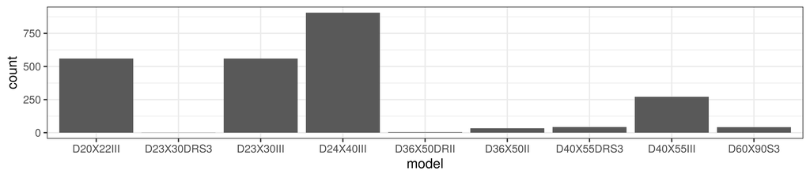

```r
summary_by_machine |>
  group_by(model) |>
  summarize(count = n()) |>
  ggplot(aes(x=model, y=count))+
  geom_bar(stat = 'identity')
```

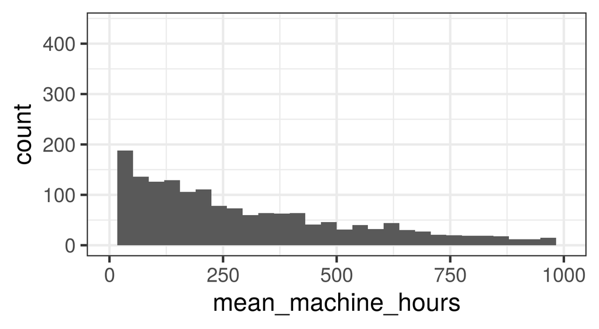

```r
#Plot histogram of mean machine hours
ggplot(summary_by_machine, aes(x=mean_machine_hours))+
  geom_histogram() +
  xlim(c(0,1000))
```

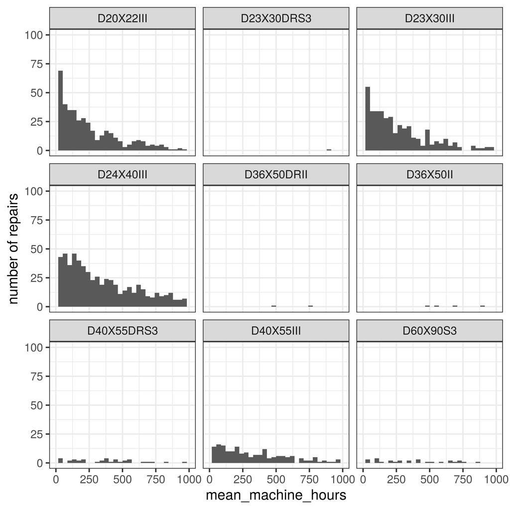

```r
#Plot histogram of mean machine hours facet by machine model
ggplot(summary_by_machine, aes(x=mean_machine_hours))+
  geom_histogram() +
  xlim(c(0,1000)) +
  ylim(c(0,100))+
  facet_wrap(~model)+
  ylab('number of repairs')
```

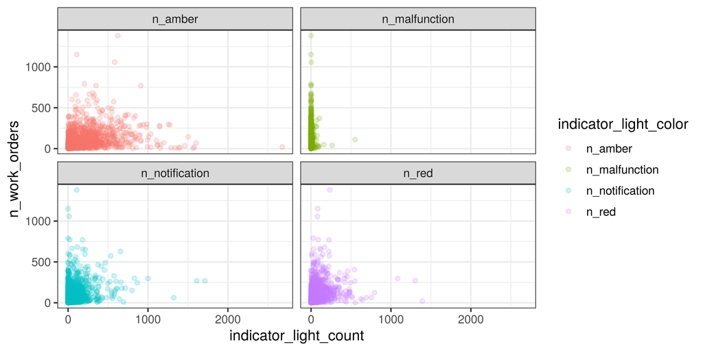

```r
summary_by_machine |>
  select(c('IDENTIFICATION', 'n_work_orders', 'n_red', 'n_amber', 'n_notification', 'n_malfunction', 'model')) |>
  pivot_longer(c(n_red,n_amber,n_notification,n_malfunction),
               names_to = 'indicator_light_color',
               values_to = 'indicator_light_count') |>
    ggplot(aes(x= indicator_light_count, y=n_work_orders, color = indicator_light_color))+
  geom_point(alpha = 0.2)+
  facet_wrap(~indicator_light_color)
```

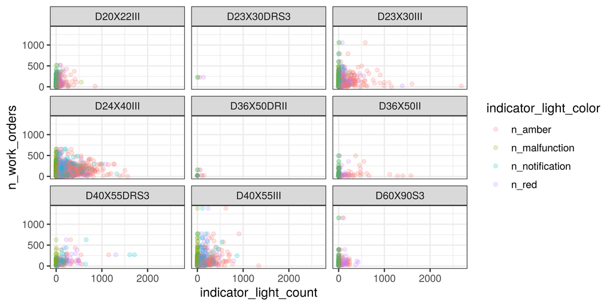

```r
summary_by_machine |>
  select(c('IDENTIFICATION', 'n_work_orders', 'n_red', 'n_amber', 'n_notification', 'n_malfunction', 'model')) |>
  pivot_longer(c(n_red,n_amber,n_notification,n_malfunction),
               names_to = 'indicator_light_color',
               values_to = 'indicator_light_count') |>
    ggplot(aes(x= indicator_light_count, y=n_work_orders, color = indicator_light_color))+
  geom_point(alpha = 0.2)+
  facet_wrap(~model)
```

## Alternative Prepare and Merge

```r
#azure_with_vin <- azure_with_vin |>
  # extract the model number (part before the :) from the variable "name"
  # but also keep "name" in the dataset too.
 # separate(name, into = c('model', NA), sep = ':', remove = FALSE)
```

## Fitting the Model:

```r
library(glmmTMB)

machine_nb1 <- glmmTMB(n_work_orders ~ median_machine_hours + median_down_time + n_red + n_amber + n_notification + n_malfunction + model,
                       data = summary_by_machine,
                       family = nbinom1(link = "log"))

machine_nb2 <- glmmTMB(n_work_orders ~ median_machine_hours + median_down_time + n_red + n_amber + n_notification + n_malfunction + model,
                       data = summary_by_machine,
                       family = nbinom2(link = "log"))
```

```r
summary(machine_nb1)
```

```
##  Family: nbinom1  ( log )
## Formula:
## n_work_orders ~ median_machine_hours + median_down_time + n_red +
##     n_amber + n_notification + n_malfunction + model
## Data: summary_by_machine
##
##      AIC      BIC   logLik deviance df.resid
##  25452.0  25544.7 -12710.0  25420.0     2405
##
##
## Dispersion parameter for nbinom1 family ():   64
##
## Conditional model:
##                        Estimate Std. Error z value Pr(>|z|)
## (Intercept)           3.986e+00  3.900e-02  102.20  < 2e-16 ***
## median_machine_hours  3.988e-04  1.904e-05   20.94  < 2e-16 ***
## median_down_time      3.114e-05  4.029e-05    0.77   0.4396
## n_red                 4.144e-04  1.624e-04    2.55   0.0107 *
## n_amber               2.585e-04  8.282e-05    3.12   0.0018 **
## n_notification        2.399e-04  1.123e-04    2.14   0.0327 *
## n_malfunction         1.864e-03  7.333e-04    2.54   0.0110 *
## modelD23X30DRS3       1.037e+00  4.739e-01    2.19   0.0287 *
## modelD23X30III        8.876e-02  4.767e-02    1.86   0.0626 .
## modelD24X40III        5.547e-02  4.494e-02    1.23   0.2171
## modelD36X50DRII      -3.660e-01  3.968e-01   -0.92   0.3563
## modelD36X50II        -1.104e+00  1.543e-01   -7.15 8.65e-13 ***
## modelD40X55DRS3       4.886e-01  1.084e-01    4.51 6.62e-06 ***
## modelD40X55III        2.406e-01  5.533e-02    4.35 1.37e-05 ***
## modelD60X90S3         1.340e-01  1.179e-01    1.14   0.2555
## ---
## Signif. codes:  0 '***' 0.001 '**' 0.01 '*' 0.05 '.' 0.1 ' ' 1
```

```r
summary(machine_nb2)
```

```
##  Family: nbinom2  ( log )
## Formula:
## n_work_orders ~ median_machine_hours + median_down_time + n_red +
##     n_amber + n_notification + n_malfunction + model
## Data: summary_by_machine
##
##      AIC      BIC   logLik deviance df.resid
##  24918.4  25011.1 -12443.2  24886.4     2405
##
##
## Dispersion parameter for nbinom2 family (): 1.39
##
## Conditional model:
##                        Estimate Std. Error z value Pr(>|z|)
## (Intercept)           3.525e+00  4.260e-02   82.74  < 2e-16 ***
## median_machine_hours  9.182e-04  2.920e-05   31.45  < 2e-16 ***
## median_down_time      6.932e-05  5.255e-05    1.32 0.187135
## n_red                 6.659e-04  3.107e-04    2.14 0.032115 *
## n_amber               5.084e-04  1.362e-04    3.73 0.000189 ***
## n_notification        7.977e-04  2.291e-04    3.48 0.000499 ***
## n_malfunction         2.201e-03  1.551e-03    1.42 0.155814
## modelD23X30DRS3       7.238e-01  8.541e-01    0.85 0.396745
## modelD23X30III        2.258e-01  5.346e-02    4.22 2.40e-05 ***
## modelD24X40III       -3.579e-02  5.246e-02   -0.68 0.495104
## modelD36X50DRII      -8.525e-01  4.351e-01   -1.96 0.050057 .
## modelD36X50II        -1.309e+00  1.696e-01   -7.72 1.17e-14 ***
## modelD40X55DRS3       5.245e-01  1.455e-01    3.61 0.000312 ***
## modelD40X55III        2.171e-01  6.671e-02    3.25 0.001136 **
## modelD60X90S3         7.128e-01  1.397e-01    5.10 3.37e-07 ***
## ---
## Signif. codes:  0 '***' 0.001 '**' 0.01 '*' 0.05 '.' 0.1 ' ' 1
```

If you go based off of AIC, negative binomial 2 is too, so, we will be using that dataset.

## Model Assessment:

With count data, the data is being assessed over three different topics: the mean-variance relationship, the independence of residuals, and log-linearity.

### Mean Varaince Relationships:

[figure not shown]

```r
library(DHARMa)

nb2_sim <- simulateResiduals(machine_nb2)
plotResiduals(nb2_sim,
              quantreg = FALSE)
```

### Independence of Residuals:

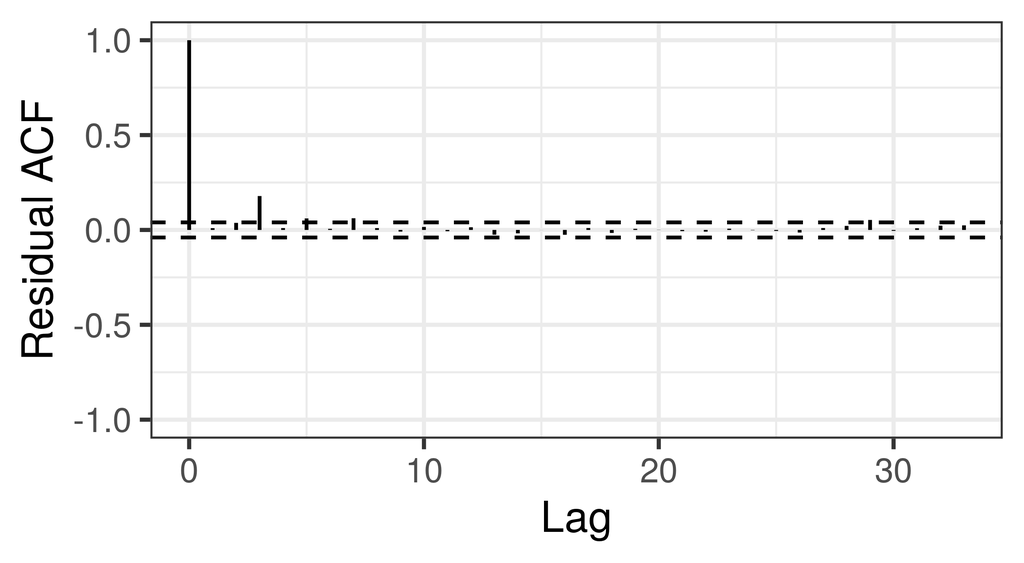

```r
s245::gf_acf(~machine_nb2) %>%
  gf_lims(y = c(-1,1))
```

There is some evidence of dependence in the residuals which we haven’t been able to account for but it could always be worse so this test doesn’t fail

### Log-Linearity:

Check log-linearity condition of predictor-response relationships

```r
loglin1 <- gf_point(log(n_work_orders) ~ median_machine_hours, data = summary_by_machine) |>
  gf_labs(
    x = "median machine hours",
    y = "Log of number of work orders"
  )
```

```r
loglin2 <- gf_point(log(n_work_orders) ~ median_down_time, data = summary_by_machine) |>
  gf_labs(
    x = "median down time",
    y = "Log of number of work orders"
  )
```

```r
loglin3 <- gf_point(log(n_work_orders) ~ model, data = summary_by_machine) |>
  gf_labs(
    x = "median down time",
    y = "Log of number of work orders"
  )
```

```r
loglin4 <- gf_point(log(n_work_orders) ~ n_red, data = summary_by_machine) |>
  gf_labs(
    x = "number of red indicator lights",
    y = "Log of number of work orders"
  )
```

```r
loglin5 <- gf_point(log(n_work_orders) ~ n_amber, data = summary_by_machine) |>
  gf_labs(
    x = "number of amber indicator lights",
    y = "Log of number of work orders"
  )
```

```r
loglin6 <- gf_point(log(n_work_orders) ~ n_notification, data = summary_by_machine) |>
  gf_labs(
    x = "number of notification indicator lights",
    y = "Log of number of work orders"
  )
```

```r
loglin7 <- gf_point(log(n_work_orders) ~ n_malfunction, data = summary_by_machine) |>
  gf_labs(
    x = "number of malfunction indicator lights",
    y = "Log of number of work orders"
  )
```

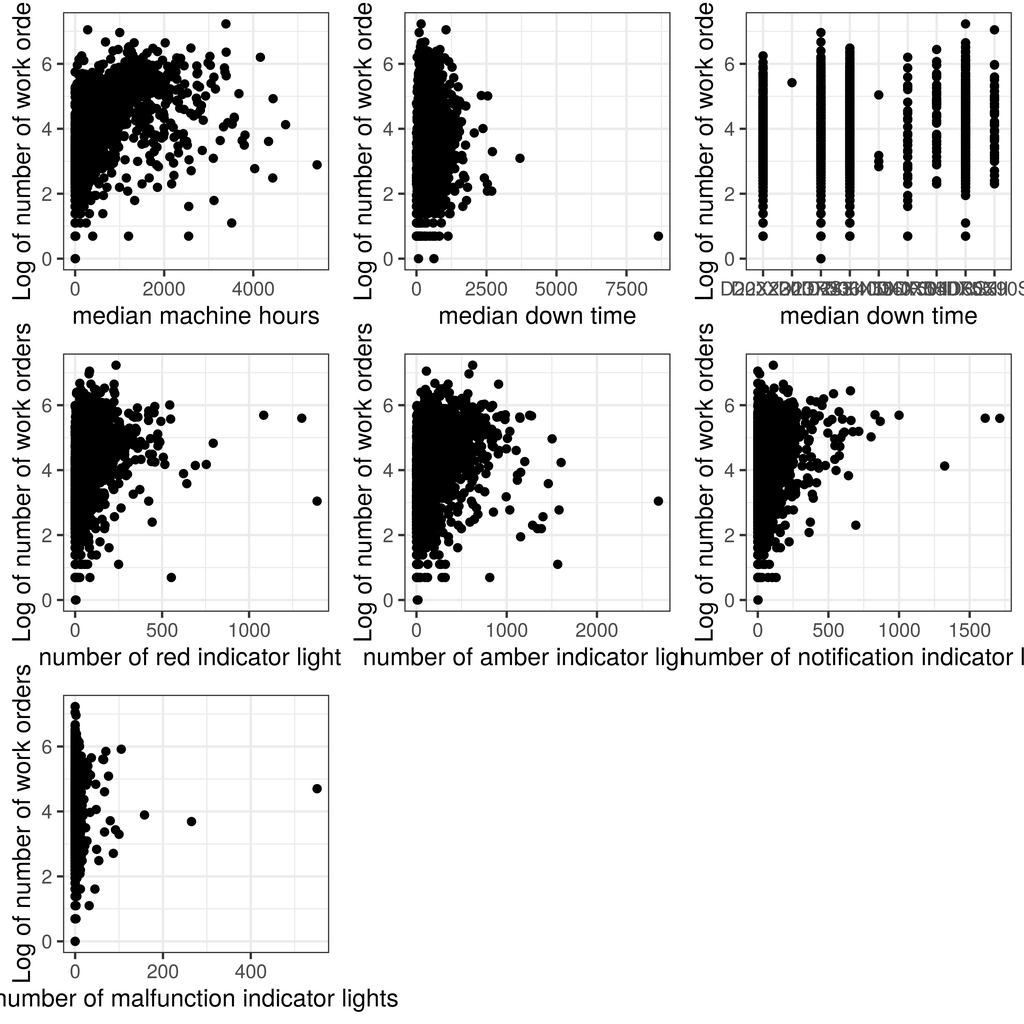

```r
require(ggpubr)
ggarrange(loglin1,loglin2,loglin3,loglin4,loglin5,loglin6,loglin7,
          ncol = 3, nrow = 3
          )
```

### Model Selection

```r
machine_nb2 <- update(machine_nb2, na.action = 'na.fail')
machine_nb2_dredge <- MuMIn::dredge(machine_nb2, rank = 'AIC')
machine_nb2_dredge
```

```
## Global model call: glmmTMB(formula = n_work_orders ~ median_machine_hours + median_down_time +
##     n_red + n_amber + n_notification + n_malfunction + model,
##     data = summary_by_machine, family = nbinom2(link = "log"),
##     ziformula = ~0, dispformula = ~1, na.action = "na.fail")
## ---
## Model selection table
##     cnd((Int)) dsp((Int)) cnd(mdn_dwn_tim) cnd(mdn_mch_hrs) cnd(mdl) cnd(n_amb)
## 127      3.547          +                         0.0009194        +  0.0005095
## 111      3.562          +                         0.0009205        +  0.0005298
## 128      3.525          +        6.932e-05        0.0009182        +  0.0005084
## 112      3.541          +        6.837e-05        0.0009193        +  0.0005289
## 63       3.556          +                         0.0009304        +  0.0006361
## 47       3.572          +                         0.0009318        +  0.0006573
## 64       3.535          +        6.743e-05        0.0009294        +  0.0006360
## 48       3.551          +        6.654e-05        0.0009307        +  0.0006573
```

[output cut: 250 more lines]